# ФББ - R - Домашнее задание №2

Данил Сидиков

19.09.2023

# Подгрузка пакетов

```r
library('tidyverse') #загрузим установленный пакет tidyverse в текущую R сессию
library("openintro") #загрузим установленный пакет openintro в текущую R сессию для работы с датасетом nycflights
```

# Задание №1

> Воспользуйтесь набором данных **nycflights** из пакета **openintro**. Примените к данным **nycflights** функцию **glimpse()**.

> Выведите результат полностью.

```r
head(nycflights)
```

```
## # A tibble: 6 x 16
##    year month   day dep_time dep_delay arr_time arr_delay carrier tailnum flight
##   <int> <int> <int>    <int>     <dbl>    <int>     <dbl> <chr>   <chr>    <int>
## 1  2013     6    30      940        15     1216        -4 VX      N626VA     407
## 2  2013     5     7     1657        -3     2104        10 DL      N3760C     329
## 3  2013    12     8      859        -1     1238        11 DL      N712TW     422
## 4  2013     5    14     1841        -4     2122       -34 DL      N914DL    2391
## 5  2013     7    21     1102        -3     1230        -8 9E      N823AY    3652
## 6  2013     1     1     1817        -3     2008         3 AA      N3AXAA     353
## # i 6 more variables: origin <chr>, dest <chr>, air_time <dbl>, distance <dbl>,
## #   hour <dbl>, minute <dbl>
```

```r
glimpse(nycflights) # применим функцию glimpse()
```

```
## Rows: 32,735
## Columns: 16
## $ year      <int> 2013, 2013, 2013, 2013, 2013, 2013, 2013, 2013, 2013, 2013, ~
## $ month     <int> 6, 5, 12, 5, 7, 1, 12, 8, 9, 4, 6, 11, 4, 3, 10, 1, 2, 8, 10~
## $ day       <int> 30, 7, 8, 14, 21, 1, 9, 13, 26, 30, 17, 22, 26, 25, 21, 23, ~
## $ dep_time  <int> 940, 1657, 859, 1841, 1102, 1817, 1259, 1920, 725, 1323, 940~
## $ dep_delay <dbl> 15, -3, -1, -4, -3, -3, 14, 85, -10, 62, 5, 5, -2, 115, -4, ~
## $ arr_time  <int> 1216, 2104, 1238, 2122, 1230, 2008, 1617, 2032, 1027, 1549, ~
## $ arr_delay <dbl> -4, 10, 11, -34, -8, 3, 22, 71, -8, 60, -4, -2, 22, 91, -6, ~
## $ carrier   <chr> "VX", "DL", "DL", "DL", "9E", "AA", "WN", "B6", "AA", "EV", ~
## $ tailnum   <chr> "N626VA", "N3760C", "N712TW", "N914DL", "N823AY", "N3AXAA", ~
## $ flight    <int> 407, 329, 422, 2391, 3652, 353, 1428, 1407, 2279, 4162, 20, ~
## $ origin    <chr> "JFK", "JFK", "JFK", "JFK", "LGA", "LGA", "EWR", "JFK", "LGA~
## $ dest      <chr> "LAX", "SJU", "LAX", "TPA", "ORF", "ORD", "HOU", "IAD", "MIA~
## $ air_time  <dbl> 313, 216, 376, 135, 50, 138, 240, 48, 148, 110, 50, 161, 87,~
## $ distance  <dbl> 2475, 1598, 2475, 1005, 296, 733, 1411, 228, 1096, 820, 264,~
## $ hour      <dbl> 9, 16, 8, 18, 11, 18, 12, 19, 7, 13, 9, 13, 8, 20, 12, 20, 6~
## $ minute    <dbl> 40, 57, 59, 41, 2, 17, 59, 20, 25, 23, 40, 20, 9, 54, 17, 24~
```

# Задание №2

> Есть ли в данных **nycflights** пропущенные значения?

> Используя функции **базового R** выведите сумму пропущенных значений в наборе данных.

```r
anyNA(nycflights) # Есть ли пропущенные значения?
```

```
## [1] FALSE
```

```r
sum(is.na(nycflights)) # Сумма пропущенных значений
```

```
## [1] 0
```

# Задание №3

> Для фильтрации строк по условию используйте функцию **filter()**.

> Отберите из набора данных ***nycflights** **июньские** (столбец month) рейсы, которые вылетели (столбец origin) из аэропорта **JFK** и прилетели (столбец dest) в аэропорты **LAX** или **ROC**. Выполните фильтрацию за одну команду. Покажите, что вы точно отобрали только нужные аэропорты.

> Сколько рейсов подходят под условия?

```r
sort_flights <- filter(nycflights, month == 6 & origin == 'JFK' & (dest == "LAX" | dest == "ROC")) # отберем данные по условию
#Убедимся, что мы точно отобрали, то что нужно
table(sort_flights$month)
```

```
##
##   6
## 109
```

```r
table(sort_flights$origin)
```

```
##
## JFK
## 109
```

```r
table(sort_flights$dest)
```

```
##
## LAX ROC
##  96  13
```

```r
dim(sort_flights)[1] # столько рейсов подходят под условия
```

```
## [1] 109
```

# Задание №4

> Для выбора колонок по индексу и имени используйте функцию **select()** Давайте начнем с **индексов**. Воспользуйтесь подвыборкой рейсов, полученных в задании №3. Отберите наиболее оптимальным способом первую, вторую, третью, одиннадцатую и двенадцатую колонки.

```r
head(sort_flights) # подвыборка рейсов из задания №3
```

```
## # A tibble: 6 x 16
##    year month   day dep_time dep_delay arr_time arr_delay carrier tailnum flight
##   <int> <int> <int>    <int>     <dbl>    <int>     <dbl> <chr>   <chr>    <int>
## 1  2013     6    30      940        15     1216        -4 VX      N626VA     407
## 2  2013     6    17      940         5     1050        -4 B6      N351JB      20
## 3  2013     6    18     1838       103     2209       124 VX      N634VA     413
## 4  2013     6    14     1259        -1     1547        -8 VX      N642VA     411
## 5  2013     6    11     1934        24     2212       -28 AA      N338AA      21
## 6  2013     6    13     1028        -2     1353        28 AA      N339AA      19
## # i 6 more variables: origin <chr>, dest <chr>, air_time <dbl>, distance <dbl>,
## #   hour <dbl>, minute <dbl>
```

```r
sq <- sort_flights
super_sort = select(sq, c(1,2,3,11,12)) #отоберем колонки по индексу с помощью вектора
head(super_sort) # теперь это наша подвыборка задания №4
```

```
## # A tibble: 6 x 5
##    year month   day origin dest
##   <int> <int> <int> <chr>  <chr>
## 1  2013     6    30 JFK    LAX
## 2  2013     6    17 JFK    ROC
## 3  2013     6    18 JFK    LAX
## 4  2013     6    14 JFK    LAX
## 5  2013     6    11 JFK    LAX
## 6  2013     6    13 JFK    LAX
```

# Задание №5

> Теперь отберем колонки по **имени**. Воспользуйтесь подвыборкой рейсов, полученных в задании №3.

> Удалите колонку с аэропортами, куда прилетали рейсы.

```r
head(sort_flights) # подвыборка рейсов из задания №3
```

```
## # A tibble: 6 x 16
##    year month   day dep_time dep_delay arr_time arr_delay carrier tailnum flight
##   <int> <int> <int>    <int>     <dbl>    <int>     <dbl> <chr>   <chr>    <int>
## 1  2013     6    30      940        15     1216        -4 VX      N626VA     407
## 2  2013     6    17      940         5     1050        -4 B6      N351JB      20
## 3  2013     6    18     1838       103     2209       124 VX      N634VA     413
## 4  2013     6    14     1259        -1     1547        -8 VX      N642VA     411
## 5  2013     6    11     1934        24     2212       -28 AA      N338AA      21
## 6  2013     6    13     1028        -2     1353        28 AA      N339AA      19
## # i 6 more variables: origin <chr>, dest <chr>, air_time <dbl>, distance <dbl>,
## #   hour <dbl>, minute <dbl>
```

```r
sq <- sort_flights
sort2 = select(sq, year, month, day, origin, dest) #отоберем колонки по имени
head(sort2)
```

```
## # A tibble: 6 x 5
##    year month   day origin dest
##   <int> <int> <int> <chr>  <chr>
## 1  2013     6    30 JFK    LAX
## 2  2013     6    17 JFK    ROC
## 3  2013     6    18 JFK    LAX
## 4  2013     6    14 JFK    LAX
## 5  2013     6    11 JFK    LAX
## 6  2013     6    13 JFK    LAX
```

```r
sort2$dest = NULL # удалим колонку с аэропортами, куда прилетали рейсы
head(sort2) #покажем итоговый результат
```

```
## # A tibble: 6 x 4
##    year month   day origin
##   <int> <int> <int> <chr>
## 1  2013     6    30 JFK
## 2  2013     6    17 JFK
## 3  2013     6    18 JFK
## 4  2013     6    14 JFK
## 5  2013     6    11 JFK
## 6  2013     6    13 JFK
```

# Задание №6

> Воспользуйтесь подвыборкой рейсов, полученных в задании №4.

> Оставьте только колонки, имена которых начинаются с буквы ***d**. Примените связку **select() + starts_with()**

```r
head(super_sort) # подвыборка рейсов из задания №4
```

```
## # A tibble: 6 x 5
##    year month   day origin dest
##   <int> <int> <int> <chr>  <chr>
## 1  2013     6    30 JFK    LAX
## 2  2013     6    17 JFK    ROC
## 3  2013     6    18 JFK    LAX
## 4  2013     6    14 JFK    LAX
## 5  2013     6    11 JFK    LAX
## 6  2013     6    13 JFK    LAX
```

```r
sq <- super_sort
sort_d <-select(sq,starts_with("d")) # выберем из подвыборки рейсов из задания №4 колонки, имена которых начинаются с буквы d.
head(sort_d)
```

```
## # A tibble: 6 x 2
##     day dest
##   <int> <chr>
## 1    30 LAX
## 2    17 ROC
## 3    18 LAX
## 4    14 LAX
## 5    11 LAX
## 6    13 LAX
```

# Задание №7

> Воспользуйтесь подвыборкой рейсов, полученных в задании №4.

> Оставьте только такие колонки, которые в названии содержат “_” в любом месте. Примените связку **select() + contains()**

```r
head(super_sort) # подвыборка рейсов из задания №4
```

```
## # A tibble: 6 x 5
##    year month   day origin dest
##   <int> <int> <int> <chr>  <chr>
## 1  2013     6    30 JFK    LAX
## 2  2013     6    17 JFK    ROC
## 3  2013     6    18 JFK    LAX
## 4  2013     6    14 JFK    LAX
## 5  2013     6    11 JFK    LAX
## 6  2013     6    13 JFK    LAX
```

```r
sq <- super_sort
sort__ <- select(sq,contains("_")) # выберем из подвыборки рейсов из задания №4 колонки, имена которых в названии содержат “_” в любом месте.
head(sort__)
```

```
## # A tibble: 6 x 0
```

# Задание №8

> Отбирать строки по позициям можно с помощью **функции slice()** Воспользуйтесь подвыборкой рейсов, полученных в задании №4.

> Отберите первую, пятую и десятую строки.

```r
head(super_sort) # подвыборка рейсов из задания №4
```

```
## # A tibble: 6 x 5
##    year month   day origin dest
##   <int> <int> <int> <chr>  <chr>
## 1  2013     6    30 JFK    LAX
## 2  2013     6    17 JFK    ROC
## 3  2013     6    18 JFK    LAX
## 4  2013     6    14 JFK    LAX
## 5  2013     6    11 JFK    LAX
## 6  2013     6    13 JFK    LAX
```

```r
sq <- super_sort
sq %>%
  slice(c(1,5,10)) # отберем 1,5,10 строки
```

```
## # A tibble: 3 x 5
##    year month   day origin dest
##   <int> <int> <int> <chr>  <chr>
## 1  2013     6    30 JFK    LAX
## 2  2013     6    11 JFK    LAX
## 3  2013     6     7 JFK    LAX
```

# Задание №9

> Для вывода шапки набора данных можно использовать, например, **функцию slice_head()**, аналог **функции head()** из базового R.

> Отберите первые 8 строк из полного набора данных **nycflights**.

```r
slice_head(nycflights,n=8) # отберем первые 8 строк
```

```
## # A tibble: 8 x 16
##    year month   day dep_time dep_delay arr_time arr_delay carrier tailnum flight
##   <int> <int> <int>    <int>     <dbl>    <int>     <dbl> <chr>   <chr>    <int>
## 1  2013     6    30      940        15     1216        -4 VX      N626VA     407
## 2  2013     5     7     1657        -3     2104        10 DL      N3760C     329
## 3  2013    12     8      859        -1     1238        11 DL      N712TW     422
## 4  2013     5    14     1841        -4     2122       -34 DL      N914DL    2391
## 5  2013     7    21     1102        -3     1230        -8 9E      N823AY    3652
## 6  2013     1     1     1817        -3     2008         3 AA      N3AXAA     353
## 7  2013    12     9     1259        14     1617        22 WN      N218WN    1428
## 8  2013     8    13     1920        85     2032        71 B6      N284JB    1407
## # i 6 more variables: origin <chr>, dest <chr>, air_time <dbl>, distance <dbl>,
## #   hour <dbl>, minute <dbl>
```

# Задание №10

> **Функция slice_sample()** помогает сделать случайный выбор строк разными способами.

> Выберите случайным образом 10 строк из полного набора данных **nycflights**.

```r
set.seed(123) # установим значение генератора для воспроизводимости
slice_sample(nycflights,n=10) # выберем случайным образом 10 строк
```

```
## # A tibble: 10 x 16
##     year month   day dep_time dep_delay arr_time arr_delay carrier tailnum
##    <int> <int> <int>    <int>     <dbl>    <int>     <dbl> <chr>   <chr>
##  1  2013     2    20     1630         0     1839         6 B6      N324JB
##  2  2013     1    25     1157        -3     1536         7 DL      N706TW
##  3  2013     4    26     1557        -3     1724         4 AA      N3AKAA
##  4  2013     9    15      744         9     1027        -8 AA      N3BAAA
##  5  2013    12    17      845         0     1115        22 US      N705UW
##  6  2013     3    17       17        84      134        80 B6      N583JB
##  7  2013     7    17      921         6     1154       -21 VX      N846VA
##  8  2013     4    24      938        83     1133        83 US      N669AW
##  9  2013     9     1     1024        -6     1321       -19 VX      N526VA
## 10  2013     1     7      803        -7     1029       -13 DL      N344NB
## # i 7 more variables: flight <int>, origin <chr>, dest <chr>, air_time <dbl>,
## #   distance <dbl>, hour <dbl>, minute <dbl>
```

# Задание №11

> Отберите случайным образом **10% строк** из набора данных **nycflights**. Для выполнения задания исследуйте параметры **функции slice_sample()**.

```r
set.seed(123) # установим значение генератора для воспроизводимости
slice_sample(nycflights,prop = 0.1) # отоберем случайным образом 10% строк
```

```
## # A tibble: 3,273 x 16
##     year month   day dep_time dep_delay arr_time arr_delay carrier tailnum
##    <int> <int> <int>    <int>     <dbl>    <int>     <dbl> <chr>   <chr>
##  1  2013     2    20     1630         0     1839         6 B6      N324JB
##  2  2013     1    25     1157        -3     1536         7 DL      N706TW
##  3  2013     4    26     1557        -3     1724         4 AA      N3AKAA
##  4  2013     9    15      744         9     1027        -8 AA      N3BAAA
##  5  2013    12    17      845         0     1115        22 US      N705UW
##  6  2013     3    17       17        84      134        80 B6      N583JB
##  7  2013     7    17      921         6     1154       -21 VX      N846VA
##  8  2013     4    24      938        83     1133        83 US      N669AW
##  9  2013     9     1     1024        -6     1321       -19 VX      N526VA
## 10  2013     1     7      803        -7     1029       -13 DL      N344NB
## # i 3,263 more rows
## # i 7 more variables: flight <int>, origin <chr>, dest <chr>, air_time <dbl>,
## #   distance <dbl>, hour <dbl>, minute <dbl>
```

# Задание №12

> Обратите внимание на **параметр weight_by функции slice_sample()**.

> Для чего он нужен? Продемонстрируйте его работу на любом примере.

> **Параметр weight_by** в **функции slice_sample()** используется для взвешивания вероятности выбора каждого элемента при выборке из набора данных. Это означает, что, когда вы используете этот параметр, каждый элемент в вашем наборе данных будет иметь разные вероятности быть выбранным в зависимости от значения, которое вы установите с помощью **weight_by**.

```r
# Создание примера набора данных
data <- data.frame(
  x = c(1, 2, 3, 4, 5),
  y = c(5, 4, 3, 2, 1)
)

# Применение slice_sample с параметром weight_by
set.seed(123)
result <- data %>%
  slice_sample(n = 2, weight_by = y)
result
```

```
##   x y
## 1 1 5
## 2 4 2
```

> В этом примере **slice_sample()** выбирает два элемента из набора данных data. **Параметр weight_by = y** означает, что вероятность выбора каждого элемента прямо пропорциональна его значению y. Таким образом, строка с y = 5 имеет наибольшую вероятность быть выбранной, а строка с y = 1 - наименьшую.

# Задание №13

> Воспользуйтесь подвыборкой рейсов, полученных в задании №4. Выберите столбец **tailnum** двумя способами: с помощью **функций pull() и select()**. В чем разница?

```r
head(sort_flights) # подвыборка рейсов из задания №4(не подходит, так как там нет столбца tailnum, поэтому выбираю подвыборку рейсов из задания №3)
```

```
## # A tibble: 6 x 16
##    year month   day dep_time dep_delay arr_time arr_delay carrier tailnum flight
##   <int> <int> <int>    <int>     <dbl>    <int>     <dbl> <chr>   <chr>    <int>
## 1  2013     6    30      940        15     1216        -4 VX      N626VA     407
## 2  2013     6    17      940         5     1050        -4 B6      N351JB      20
## 3  2013     6    18     1838       103     2209       124 VX      N634VA     413
## 4  2013     6    14     1259        -1     1547        -8 VX      N642VA     411
## 5  2013     6    11     1934        24     2212       -28 AA      N338AA      21
## 6  2013     6    13     1028        -2     1353        28 AA      N339AA      19
## # i 6 more variables: origin <chr>, dest <chr>, air_time <dbl>, distance <dbl>,
## #   hour <dbl>, minute <dbl>
```

```r
sq <- sort_flights
sq %>%
  select(tailnum) %>% head(5) #выбираем с помощью select
```

```
## # A tibble: 5 x 1
##   tailnum
##   <chr>
## 1 N626VA
## 2 N351JB
## 3 N634VA
## 4 N642VA
## 5 N338AA
```

```r
sq %>%
  pull(tailnum) %>% head(5) #выбираем с помощью pull
```

```
## [1] "N626VA" "N351JB" "N634VA" "N642VA" "N338AA"
```

> **pull()** используется для извлечения одного столбца из набора данных и возвращает его как вектор.

> **select()** используется для выбора одного или нескольких столбцов из набора данных и возвращает их как новый набор данных.

# Задание №14

> С помощью **функции arrange()** можно отсортировать данные по одному или нескольким столбцам по убыванию ли возрастанию. Воспользуйтесь подвыборкой рейсов, полученных в задании №4.

> Отсортируйте набор данных по столбцу **day** по **убыванию**.

```r
head(super_sort) # подвыборка рейсов из задания №4
```

```
## # A tibble: 6 x 5
##    year month   day origin dest
##   <int> <int> <int> <chr>  <chr>
## 1  2013     6    30 JFK    LAX
## 2  2013     6    17 JFK    ROC
## 3  2013     6    18 JFK    LAX
## 4  2013     6    14 JFK    LAX
## 5  2013     6    11 JFK    LAX
## 6  2013     6    13 JFK    LAX
```

```r
sq <- super_sort
sq %>%
  arrange(desc(day)) # отсортируем набор данных по столбцу day по убыванию
```

```
## # A tibble: 109 x 5
##     year month   day origin dest
##    <int> <int> <int> <chr>  <chr>
##  1  2013     6    30 JFK    LAX
##  2  2013     6    30 JFK    LAX
##  3  2013     6    30 JFK    LAX
##  4  2013     6    30 JFK    LAX
##  5  2013     6    30 JFK    LAX
##  6  2013     6    29 JFK    LAX
##  7  2013     6    29 JFK    LAX
##  8  2013     6    28 JFK    LAX
##  9  2013     6    28 JFK    LAX
## 10  2013     6    27 JFK    LAX
## # i 99 more rows
```

# Задание №15

> Добавить новый столбец к набору данных можно с помощью **функции mutate()**. Воспользуйтесь подвыборкой рейсов, полученных в задании №4.

> Добавьте к данным столбец YMD, который представляет собой слияние столбцов **year, month, day вида: year_month_day (пример: 2023_9_18)**.

```r
head(super_sort) # подвыборка рейсов из задания №4
```

```
## # A tibble: 6 x 5
##    year month   day origin dest
##   <int> <int> <int> <chr>  <chr>
## 1  2013     6    30 JFK    LAX
## 2  2013     6    17 JFK    ROC
## 3  2013     6    18 JFK    LAX
## 4  2013     6    14 JFK    LAX
## 5  2013     6    11 JFK    LAX
## 6  2013     6    13 JFK    LAX
```

```r
sq <- super_sort
sq %>%
  mutate(YMD = paste(year,month,day, sep="_")) %>% head(3) # добавим к данным столбец YMD c указанным форматом
```

```
## # A tibble: 3 x 6
##    year month   day origin dest  YMD
##   <int> <int> <int> <chr>  <chr> <chr>
## 1  2013     6    30 JFK    LAX   2013_6_30
## 2  2013     6    17 JFK    ROC   2013_6_17
## 3  2013     6    18 JFK    LAX   2013_6_18
```

# Задание №16

> С помощью **функции transmute()** можно создать новые колонки, удалив при этом все колонки, которые были раньше. Воспользуйтесь исходными данными **nycflights**. Создайте и оставьте только колонки:

> **YMD**: аналогичная описанной в задании №15

> **dep_delay_abs**: абсолютные значения колонки dep_delay

> **arr_delay_abs**: абсолютные значения колонки arr_delay.

```r
nycflights %>%
  transmute(YMD = paste(year,month,day,sep="_"), #используем transmute()
            dep_delay_abs = abs(dep_delay), # берем абсолютные значения dep и arr _delay
            arr_delay_abs = abs(arr_delay)) %>% head(3)
```

```
## # A tibble: 3 x 3
##   YMD       dep_delay_abs arr_delay_abs
##   <chr>             <dbl>         <dbl>
## 1 2013_6_30            15             4
## 2 2013_5_7              3            10
## 3 2013_12_8             1            11
```

# Задание №17

> Переименовать колонки можно с помощью **функции rename()**. Воспользуйтесь исходными данными **nycflights**.

> Переименуйте колонку **dep_delay** в **Departure_delays_min**.

```r
nycflights %>%
  rename(Departure_delays_min = dep_delay) %>% head(3) # переименуем столбец
```

```
## # A tibble: 3 x 16
##    year month   day dep_time Departure_delays_min arr_time arr_delay carrier
##   <int> <int> <int>    <int>                <dbl>    <int>     <dbl> <chr>
## 1  2013     6    30      940                   15     1216        -4 VX
## 2  2013     5     7     1657                   -3     2104        10 DL
## 3  2013    12     8      859                   -1     1238        11 DL
## # i 8 more variables: tailnum <chr>, flight <int>, origin <chr>, dest <chr>,
## #   air_time <dbl>, distance <dbl>, hour <dbl>, minute <dbl>
```

# Задание №18

> Переименовать колонки можно, применив к названиям какую-то единообразную операцию.Это можно сделать с помощью **функции rename_with()**. Воспользуйтесь подвыборкой рейсов, полученных в задании №4.

> Сделайте все буквы в названиях всех колонок **заглавными**.

```r
head(super_sort) # подвыборка рейсов из задания №4
```

```
## # A tibble: 6 x 5
##    year month   day origin dest
##   <int> <int> <int> <chr>  <chr>
## 1  2013     6    30 JFK    LAX
## 2  2013     6    17 JFK    ROC
## 3  2013     6    18 JFK    LAX
## 4  2013     6    14 JFK    LAX
## 5  2013     6    11 JFK    LAX
## 6  2013     6    13 JFK    LAX
```

```r
sq <- super_sort
sq %>%
  rename_with(.fn = toupper) # используем функцию toupper, которая делает все буквы заглавными
```

```
## # A tibble: 109 x 5
##     YEAR MONTH   DAY ORIGIN DEST
##    <int> <int> <int> <chr>  <chr>
##  1  2013     6    30 JFK    LAX
##  2  2013     6    17 JFK    ROC
##  3  2013     6    18 JFK    LAX
##  4  2013     6    14 JFK    LAX
##  5  2013     6    11 JFK    LAX
##  6  2013     6    13 JFK    LAX
##  7  2013     6    14 JFK    LAX
##  8  2013     6    15 JFK    LAX
##  9  2013     6     6 JFK    LAX
## 10  2013     6     7 JFK    LAX
## # i 99 more rows
```

# Задание №19

> Оставить только уникальные строки в наборе данных или в конкретном столбце можно с помощью **функции distinct()**. Воспользуйтесь подвыборкой рейсов, полученных в задании №4.

> Выведите только уникальные значения столбца **dest**.

```r
head(super_sort) # подвыборка рейсов из задания №4
```

```
## # A tibble: 6 x 5
##    year month   day origin dest
##   <int> <int> <int> <chr>  <chr>
## 1  2013     6    30 JFK    LAX
## 2  2013     6    17 JFK    ROC
## 3  2013     6    18 JFK    LAX
## 4  2013     6    14 JFK    LAX
## 5  2013     6    11 JFK    LAX
## 6  2013     6    13 JFK    LAX
```

```r
sq <- super_sort
sq %>%
  distinct(dest) # выведем уникальные значения столбца dest
```

```
## # A tibble: 2 x 1
##   dest
##   <chr>
## 1 LAX
## 2 ROC
```

# Задание №20

> **n()** - выводит число записей.

> Отберите **последние 10 строк** из набора данных **nycflights**, используя **функцию n()**.

```r
nycflights %>%
  slice((n() - 9):n()) # отберем последние 10 строк с помощью n()
```

```
## # A tibble: 10 x 16
##     year month   day dep_time dep_delay arr_time arr_delay carrier tailnum
##    <int> <int> <int>    <int>     <dbl>    <int>     <dbl> <chr>   <chr>
##  1  2013    12    16     1437         8     1613       -10 9E      N916XJ
##  2  2013     2     4     1558        -2     1854         4 DL      N3737C
##  3  2013    10     3     1716         2     1812       -27 B6      N192JB
##  4  2013     7    13     1923        18     2124        18 9E      N922XJ
##  5  2013     1    28      706        36      909        22 EV      N13914
##  6  2013    10     8      752        -8      921       -28 9E      N8505Q
##  7  2013     7     7      812        -3     1043         8 DL      N6713Y
##  8  2013     9     3     1057        -1     1319       -19 UA      N77871
##  9  2013    10    15      844        56     1045        60 B6      N258JB
## 10  2013     3    28     1813        -3     1942       -23 UA      N36272
## # i 7 more variables: flight <int>, origin <chr>, dest <chr>, air_time <dbl>,
## #   distance <dbl>, hour <dbl>, minute <dbl>
```

# Задание №21

> Воспользуйтесь полным набором данных **nycflights**. С помощью средств базовой графики **визуализируйте количество рейсов в каждом месяце**.

> Подпишите оси и название графика.

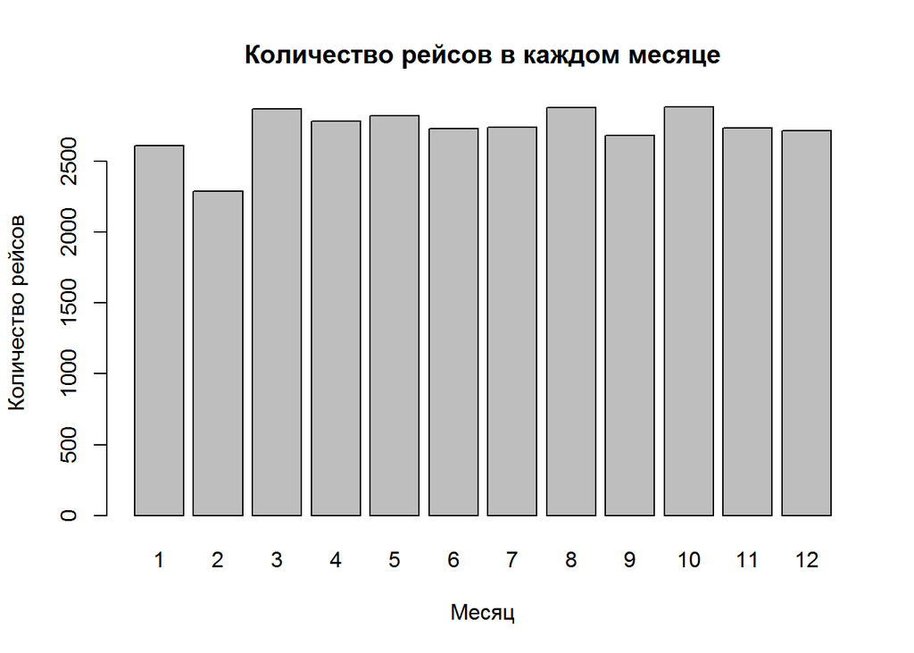

```r
barplot(table(nycflights$month), main = "Количество рейсов в каждом месяце", xlab = "Месяц", ylab = "Количество рейсов") # построим столбчатую диаграмму по месяцам.
```

# Задание №22

> Воспользуйтесь полным набором данных **nycflights**. С помощью средств базовой графики* *визуализируйте распределение времени задержки прибытия рейса (столбец arr_delay)**.

> Подпишите оси и название графика.

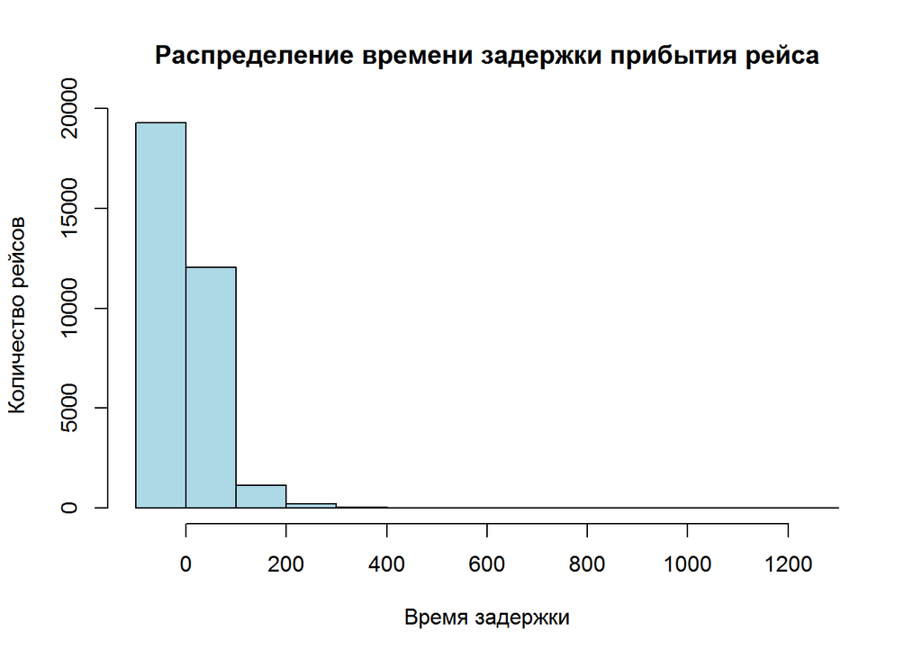

```r
hist(nycflights$arr_delay,
     main="Распределение времени задержки прибытия рейса",
     xlab="Время задержки",
     ylab="Количество рейсов",
     col="lightblue",
     border="black") # построим гистаграмму для этого
```

# Задание №23

> Воспользуйтесь полным набором данных **nycflights**. С помощью средств базовой графики **изобразите точковую диаграмму времени задержки отправления от задержки прибытия рейсов**. Добавьте **окрашивание по месяцам**.

> Подпишите оси и название графика.

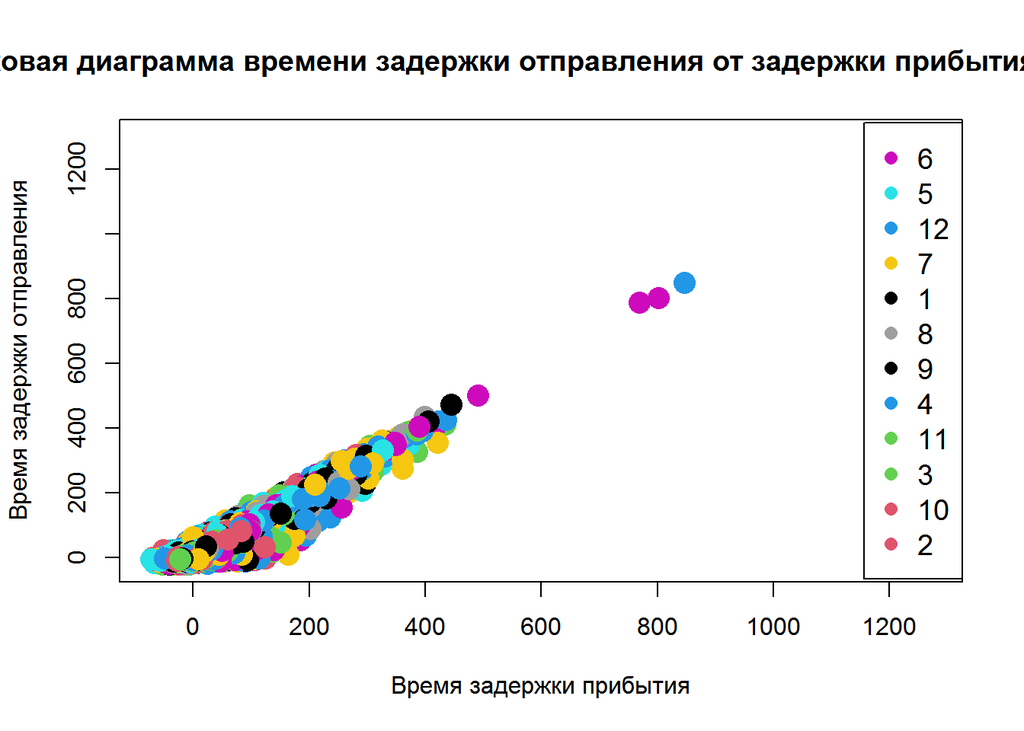

```r
plot(nycflights$arr_delay, nycflights$dep_delay, cex = 2, pch = 16,col = nycflights$month,
     main="Точковая диаграмма времени задержки отправления от задержки прибытия рейсов",
     xlab="Время задержки прибытия",
     ylab="Время задержки отправления") #строим точковую диаграмму

# Получим уникальные значения цветов
unique_colors <- unique(nycflights$month)

# Добавим легенду
legend("right", legend = unique_colors, col = unique_colors, pch = 16, cex = 1.2)
```

```r
# PS: позади легенды есть точка:)
```

# Задание №24

> Решите задание №3 с помощью базового R.

> Отберите из набора данных ***nycflights** **июньские** (столбец month) рейсы, которые вылетели (столбец origin) из аэропорта **JFK** и прилетели (столбец dest) в аэропорты **LAX** или **ROC**. Выполните фильтрацию за одну команду. Покажите, что вы точно отобрали только нужные аэропорты.

> Сколько рейсов подходят под условия?

```r
sort_flights <- nycflights[nycflights$month == 6 & nycflights$origin == 'JFK' & (nycflights$dest == "LAX" | nycflights$dest == "ROC"),] # отберем данные по условию
#Убедимся, что мы точно отобрали, то что нужно
table(sort_flights$month)
```

```
##
##   6
## 109
```

```r
table(sort_flights$origin)
```

```
##
## JFK
## 109
```

```r
table(sort_flights$dest)
```

```
##
## LAX ROC
##  96  13
```

```r
dim(sort_flights)[1] # столько рейсов подходят под условия
```

```
## [1] 109
```

# Задание №25

> > Добавьте к данным столбец YMD, который представляет собой слияние столбцов year, month, day вида: year_month_day (пример: 2023_9_18).

```r
head(super_sort) # подвыборка рейсов из задания №4
```

```
## # A tibble: 6 x 5
##    year month   day origin dest
##   <int> <int> <int> <chr>  <chr>
## 1  2013     6    30 JFK    LAX
## 2  2013     6    17 JFK    ROC
## 3  2013     6    18 JFK    LAX
## 4  2013     6    14 JFK    LAX
## 5  2013     6    11 JFK    LAX
## 6  2013     6    13 JFK    LAX
```

```r
sq <- super_sort
sq["YMD"] = paste(sq$year,sq$month,sq$day, sep="_") # добавим к данным столбец YMD c указанным форматом
head(sq,3)
```

```
## # A tibble: 3 x 6
##    year month   day origin dest  YMD
##   <int> <int> <int> <chr>  <chr> <chr>
## 1  2013     6    30 JFK    LAX   2013_6_30
## 2  2013     6    17 JFK    ROC   2013_6_17
## 3  2013     6    18 JFK    LAX   2013_6_18
```